# Welcome to the Tidyverse

### ggtitle(), labs()

Per modificare il titolo e sottotitolo possiamo usare la funzione `ggtitle()`, mentre per gli assi `xlab()` e `ylab()`

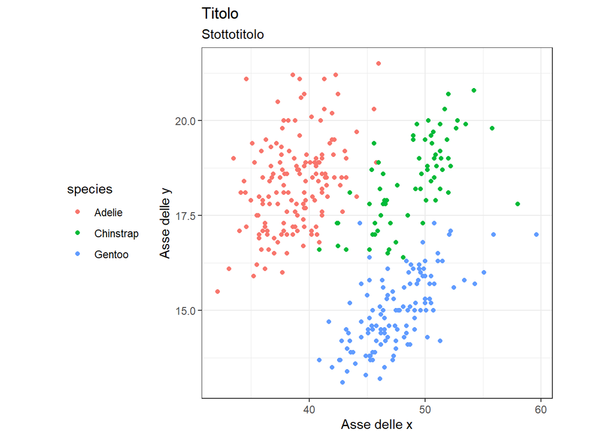

```r
penguins %>%
  ggplot(aes(x = bill_length_mm, y = bill_depth_mm, colour = species)) +
  geom_point() +
  ggtitle("Titolo", subtitle = "Stottotitolo") +
  xlab("Asse delle x") +
  ylab("Asse delle y")
```

in generale possiamo usare la funzione `labs()`per modificare tutti questi elementi e altri contemporaneamente:

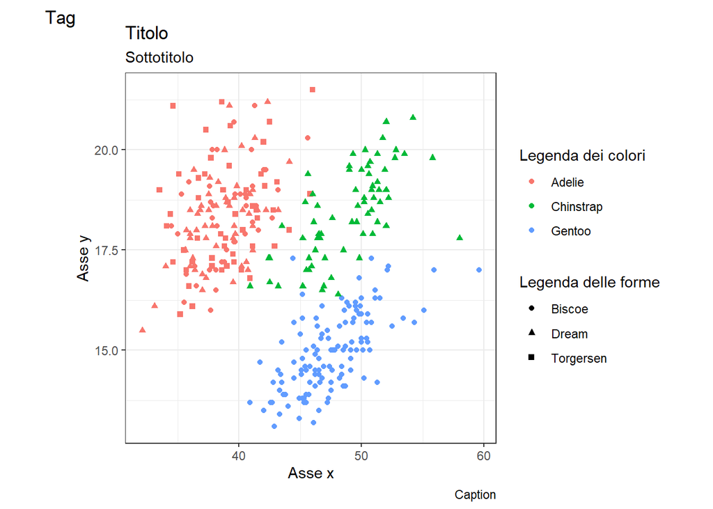

```r
penguins %>%
  ggplot(aes(x = bill_length_mm, y = bill_depth_mm, colour = species, shape = island)) +
  geom_point() +
  labs(
    title = "Titolo", subtitle = "Sottotitolo",
    caption = "Caption",
    tag = "Tag",
    x = "Asse x",
    y = "Asse y",
    colour = "Legenda dei colori",
    shape = "Legenda delle forme"
  ) + theme(legend.position = "right")
```

## BONUS: Plotly

Il pacchetto `plotly` vi consente, anche a partire da grafici ggplot, di creare grafici interattivi. Utili per l’analisi dati. Il codice non è stato eseguito perché il file sarebbe stato molto pesante, però potete copiarlo e provare in un vostro R markdown.

```r
# carico il pacchetto NB: dovete installarlo con install.packages("plotly")
library(plotly)
```

Per convertire un grafico ggplot in plotly uso la funzione `ggplotly()`. Tutti gli aes che utilizzo per ggplot saranno utilizzati anche per creare il grafico plotly, inoltre spostando il cursore su un determinato punto saranno visibili i valori delle variabili aes di quel punto.

```r
pl2 <- p1 %>%
  drop_na(bill_length_mm, bill_depth_mm) %>%
  ggplot(aes(bill_length_mm, bill_depth_mm, col = species, label = ID)) +
  geom_point() + theme_bw()

pl2 %>%
  ggplotly()
```

Altrimenti posso costruire il grafico con linguaggio plotly simile a quello di ggplot:

```r
penguins %>%
  plot_ly(
    type = "scatter3d", # tipo di grafico
    x = ~bill_length_mm, # le colonne dei valori in x, y, z e colore precedute da ~
    y = ~bill_depth_mm,
    z = ~body_mass_g,
    color = ~species,
    mode = "markers"
  )
```

Con R base possiamo creare grafici conotour per visualizzare superfici costruite con coordinate x, y, z come nella variabile volcano (variabile interna di R)

```r
volcano %>%
  filled.contour()
```

```r
plot_ly(
  type = "surface",
  z = ~volcano
)
```

Infine possiamo anche creare animazioni aggiungendo la voce frame e indicando la variabile per cui vogliamo creare diversi frame del grafico.

```r
set.seed(10); data.frame(
  id = rep(1:10,  5),
  anno = rep(2020:2024, each = 10)
) %>%
  mutate(conc = rnorm(n(), mean = id * (anno-2020)),
         temp = rnorm(n(), mean = id)
           ) %>%

  plot_ly(
    x = ~temp,
    y = ~conc,
    frame = ~anno,
    text = ~id,
    color = ~as.factor(id),
    type = "scatter",
    mode = "markers"
  )
```